# XML Vignette

Steven Miller and Clayton Ramsey

June 13, 2019

# Description of XML data

XML stands for extensible markup language. It is a method of formatting and structuring data to be able to easily share the data online. XML data is self describing, which means that the structure of the data as well as the data are embedded in the file. Therefore, an XML file contains the metadata that describes the data in addition to the actual data, which allows for the data to be read in and stored without building the structure of the data. Source: [TechTarget](https://searchmicroservices.techtarget.com/definition/XML-Extensible-Markup-Language)

XML is a format that is commonly used to provide files by API. For example, [SAX](https://searchmicroservices.techtarget.com/definition/SAX-Simple-API-for-XML) and [REST](https://blogs.mulesoft.com/dev/howto/build-rest-api-with-xml-payload/) both handle XML files. Other web services benefit from XML as a format because it allows for interactive and customizable user interfaces and is standardized internationally. Sources: [lifewire](https://www.lifewire.com/reasons-to-use-xml-3471386) and [IBM](https://www.ibm.com/support/knowledgecenter/en/ssw_ibm_i_71/rzamj/rzamjintrouses.htm).

# XML packages and functions

This xml file was read in using `xmlToList()` from the `XML` package. This package is located at [CRAN](https://cran.r-project.org/web/packages/XML/index.html). The authors are Duncan Temple Lang and the CRAN Team (including Tomas Kalibera). The package contains a variety of functions with

> “many approaches for both reading and creating XML (and HTML) documents (including DTDs), both local and accessible via HTTP or FTP. Also offers access to an ‘XPath’ ``interpreter’’.”

See https://cran.r-project.org/web/packages/XML/XML.pdf

# XML dataset

Our dataset is hosted at the [Centers for Disease Control and Prevention](https://data.cdc.gov/NCHS/NCHS-Death-rates-and-life-expectancy-at-birth/w9j2-ggv5). There are 1044 observations of 5 variables: Year, Race, Sex, Average Life Expectancy, and Age-Adjusted Death Rate. The following descriptions are from the above website.

The CDC uses the [Socrata Open Data API](https://dev.socrata.com/) for requests. However, the API token system was not working when I requested one. Fortunately, there was a way to aquire the file in raw XML format for download.

**Variables**

- Year: Dates from 1900 to 2015.
- Race: White, Black, or Both Races.
- Sex: Male, Female, or Both Sexes.
- Average Life Expectancy: For dates prior to 1968, data are biased or otherwise unreliable because of the way racial categories are formed and underreporting. See https://www.cdc.gov/nchs/nvss/mortality/hist293.htm.
- Age-Adjusted Death Rate: Calculated from the 2000 US standard population, in a variety of ways based on timeframe. See https://data.cdc.gov/NCHS/NCHS-Death-rates-and-life-expectancy-at-birth/w9j2-ggv5. Note: Age-adjusted death rate is the number of deaths per 100,000 people and is adjusted for a standard population of ages for each group.

**Variables Created**

We also decided to create two variables to better understand trends in the data. These variables are average distance from the mean life expectancy and average distance from the mean age-adjusted death rate for each year. These were calculated by subtracting the average life expectancy for each year from all observations from that year. This was repeated for the average age-adjusted death rate as well.

- Distance from Mean Life Expectancy: The overall year mean life expectancy subtracted from each subgroup from that year
- Distance from Mean Age-Adjusted Death Rate: The overall year mean age-adjusted death rate subtracted from each subgroup from that year

# Exploratory data analysis

## Tables

### Table 1

Cleaned “death rate data” from the original XML dataset  
Note: Values of `NA` were introduced by coercion and remain in this table.

|  | Year | Race | Sex | AveLifeExp | Mort |
| --- | --- | --- | --- | --- | --- |
| 1 | 2015 | All Races | Both Sexes |  | 733.1 |
| 2 | 2014 | All Races | Both Sexes | 78.9 | 724.6 |
| 3 | 2013 | All Races | Both Sexes | 78.8 | 731.9 |
| 4 | 2012 | All Races | Both Sexes | 78.8 | 732.8 |
| 5 | 2011 | All Races | Both Sexes | 78.7 | 741.3 |
| 6 | 2010 | All Races | Both Sexes | 78.7 | 747 |
| 7 | 2009 | All Races | Both Sexes | 78.5 | 749.6 |
| 8 | 2008 | All Races | Both Sexes | 78.2 | 774.9 |
| 9 | 2007 | All Races | Both Sexes | 78.1 | 775.3 |
| 10 | 2006 | All Races | Both Sexes | 77.8 | 791.8 |

[output cut: 1034 more lines]

### Table 2

The average life expectancy and age-adjusted death rates for each year from 1900 to 2015

|  | Year | Average Life Expectancy | Average Age-Adjusted Death Rate |
| --- | --- | --- | --- |
| 1 | 1900 | 47.3 | 2518 |
| 2 | 1901 | 49.1 | 2473.1 |
| 3 | 1902 | 51.5 | 2301.3 |
| 4 | 1903 | 50.5 | 2379 |
| 5 | 1904 | 47.6 | 2502.5 |
| 6 | 1905 | 48.7 | 2423.7 |
| 7 | 1906 | 48.7 | 2399 |
| 8 | 1907 | 47.6 | 2494.4 |
| 9 | 1908 | 51.1 | 2298.9 |
| 10 | 1909 | 52.1 | 2249.2 |

[output cut: 106 more lines]

### Table 3

Adjusted data set to include created variables (distance from mean life expectancy and distance from mean age-adjusted death rate)

|  | Year | Race | Sex | AveLifeExp | Mort | DistFromMeanLE | DistFromMeanMort |
| --- | --- | --- | --- | --- | --- | --- | --- |
| 1 | 1900 | Black | Male | 32.5 | 3576.5 | -14.8 | 1058.5 |
| 2 | 1900 | All Races | Male | 46.3 | 2630.8 | -1 | 112.8 |
| 3 | 1900 | White | Female | 48.7 | 2394 | 1.4 | -124 |
| 4 | 1900 | White | Both Sexes | 47.6 | 2501.2 | 0.3 | -16.8 |
| 5 | 1900 | Black | Female | 33.5 | 3308 | -13.8 | 790 |
| 6 | 1900 | Black | Both Sexes | 33 | 3423.3 | -14.3 | 905.3 |
| 7 | 1900 | All Races | Female | 48.3 | 2410.4 | 1 | -107.6 |
| 8 | 1900 | White | Male | 46.6 | 2613.2 | -0.7 | 95.2 |
| 9 | 1901 | White | Both Sexes | 49.4 | 2456.2 | 0.3 | -16.9 |
| 10 | 1901 | White | Female | 51 | 2334.7 | 1.9 | -138.4 |

[output cut: 918 more lines]

### Tables 4 and 5

Average life expectancy and age-adjusted death rate by race and sex

Table 4: Average life expectancy and age-adjusted death rate by race

| Race | Mean Life Expectancy | Average Age-Adjusted Death Rate |
| --- | --- | --- |
| All Races | 66.6 | 1488.6 |
| Black | 58.4 | 1896.1 |
| White | 67.4 | 1457.5 |

Table 5: Average life expectancy and age-adjusted death rate by sex

| Sex | Mean Life Expectancy | Average Age-Adjusted Death Rate |
| --- | --- | --- |
| Both Sexes | 64.1 | 1601.9 |
| Female | 66.7 | 1424.9 |
| Male | 61.5 | 1815.4 |

## Graphs

### Relationship between Life Expectancy and Age-Adjusted Death Rate

#### Scatterplot of Life Expectancy vs. Age-Adjusted Death Rate

The scatterplot comparing life expectancy to age-adjusted death rate shows a negative relationship between the two. This makes sense because as life expectancy increases, we would expect the age-adjusted death rate to decrease because less people are dying.

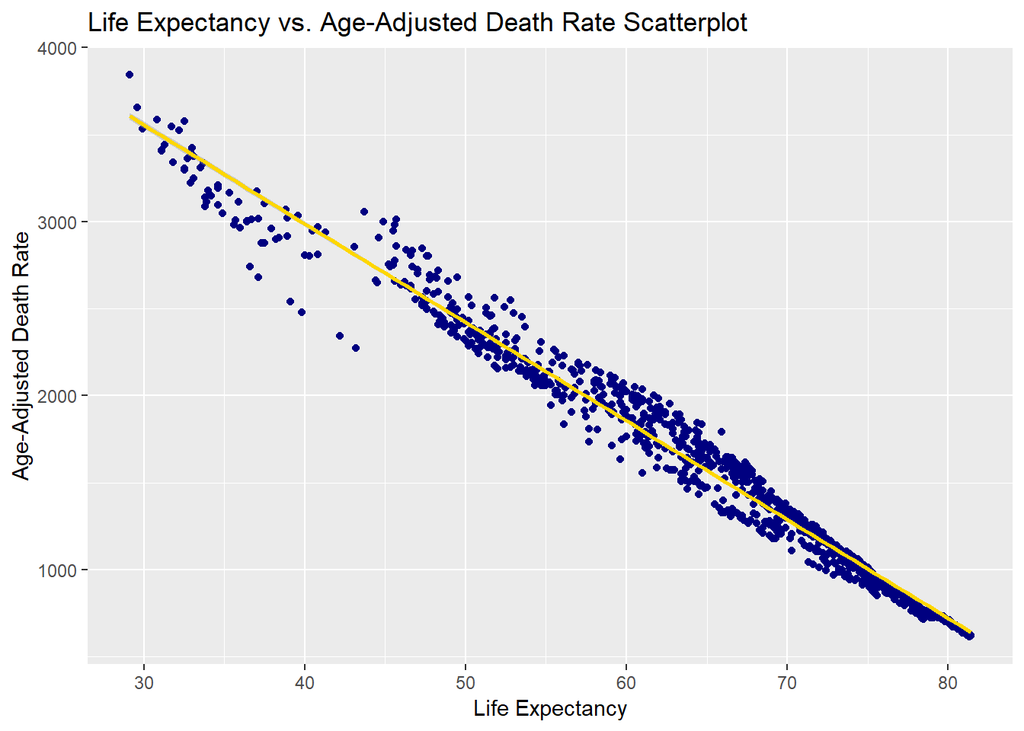

### Analysis by Year

#### Line Plots

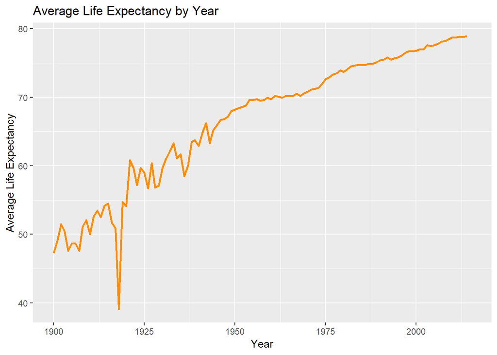

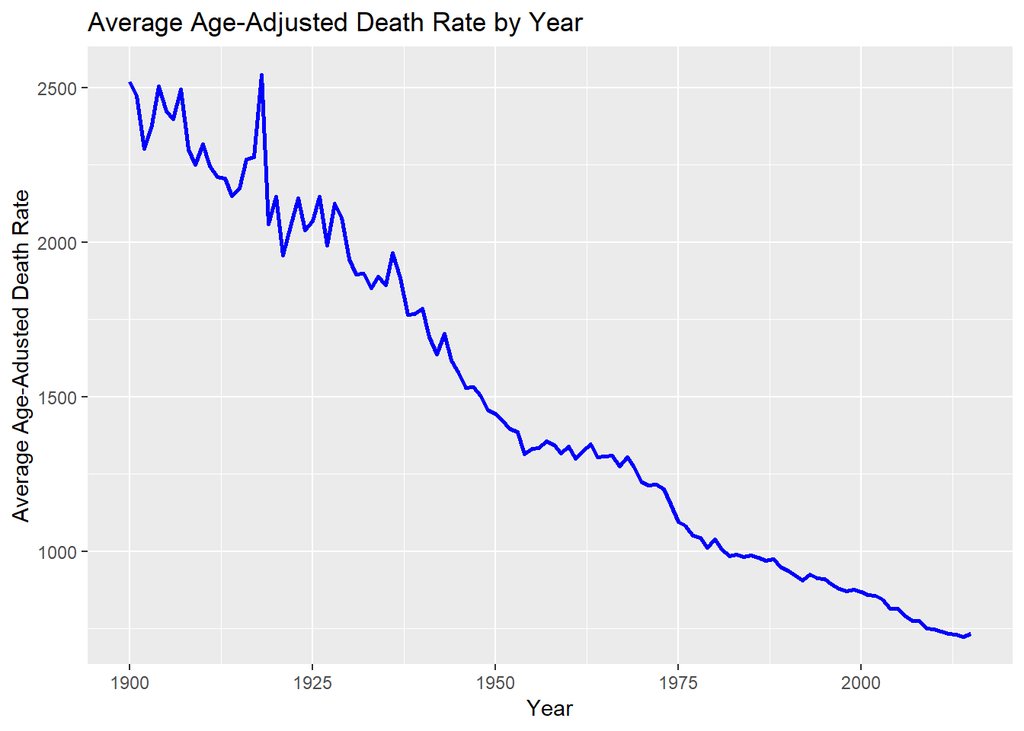

The next two line plots show the trends in life expectancy and age-adjusted death rate for each group of race and sex as the years increase. It is evident that white females have the highest life expectancy and lowest age-adjusted death rate, while black males have the lowest life expectancy and highest age-adjusted death rate. This will be confirmed by future graphs.

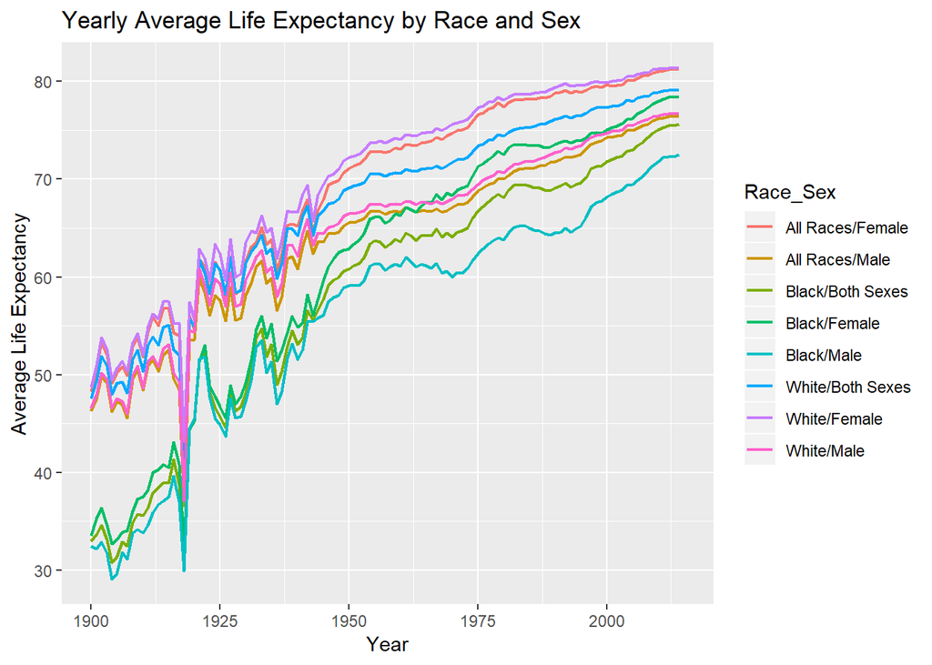

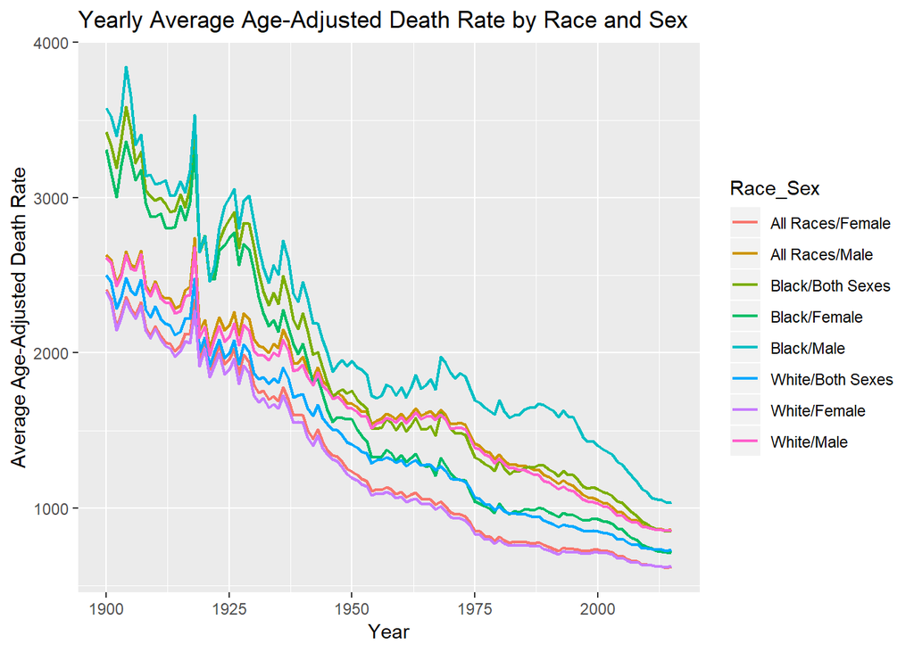

### Life Expectancy and Age-Adjusted Death Rate Analysis

#### Boxplots

The boxplots show the trends in life expectancy and age-adjusted death rate for both race and sex. These boxplots show that the average life expectancy is higher for females than males and higher for white people than black people, while the average age-adjusted death rate is lower for females than males and lower for white people than black people.

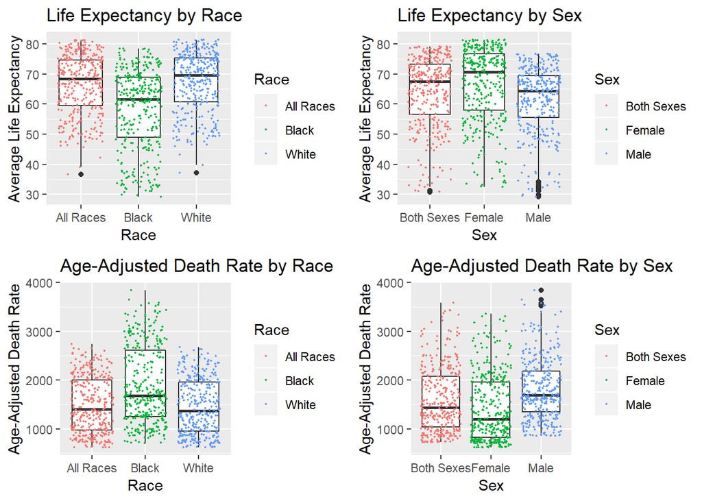

#### Side-By-Side Bar Plots

The side-by-side bar plots give a good visual representation of average life expectancy and average age-adjusted death rate by sex and race. These plots give more evidence that the females have a greater life expectancy than males, and white people have a greater life expectancy than black people. White females have the highest life expectancy, followed by white males, then black females, and finally black males. The opposite is true for average age-adjusted death rate. White females have the lowest death rate, followed by white males, then black females, and finally black males.

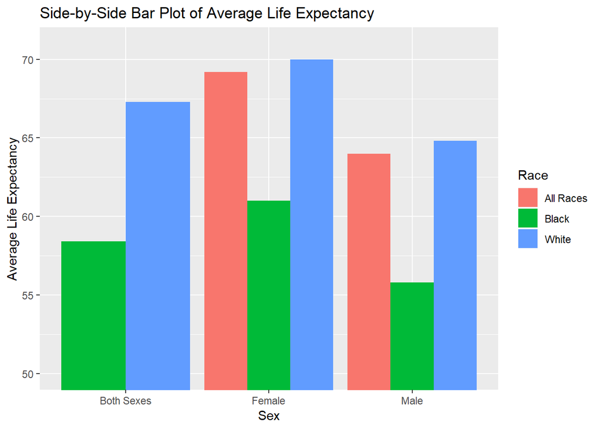

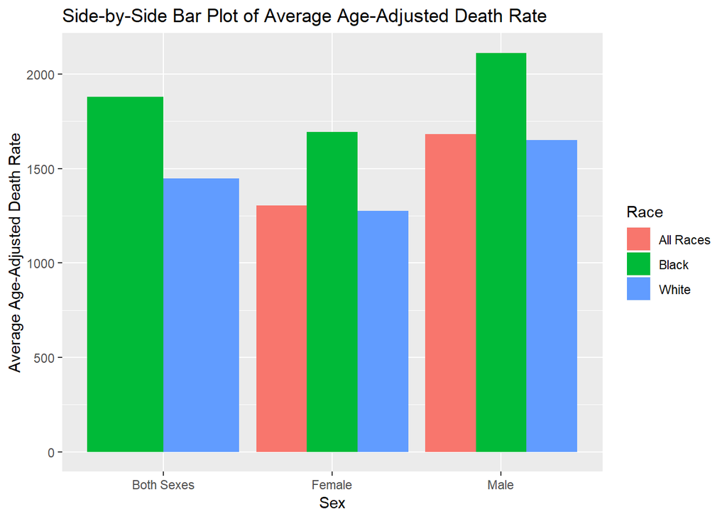

### Distance from Mean Life Expectancy and Age-Adjusted Death Rate Analysis

#### Side-By-Side Bar Plots

These last side-by-side bar plots are similar to the previous ones, but they look at the new variables we created. The mean life expectancy and age-adjusted death rate were taken for each year and then these values were subtracted from all of the observations from this year, giving us a distance from the mean for the two variables for every year.

The bar graphs show the mean distances from the mean for all of our sex and race combinations. On average, black people have a life expectancy of eight years lower than the average, while white people are about one year above the average. Females are nearly three years above the average, and males are nearly three years below it. On average, black males have a life expectancy of nearly 11 years less than the average life expectancy.

The side-by-side bar plot of average distance from mean age-adjusted death rate shows a similar pattern. On average, black males have a death rate of about 625 more deaths per 100000 people than the average. White females have about 200 less deaths per 100000 people than the average.

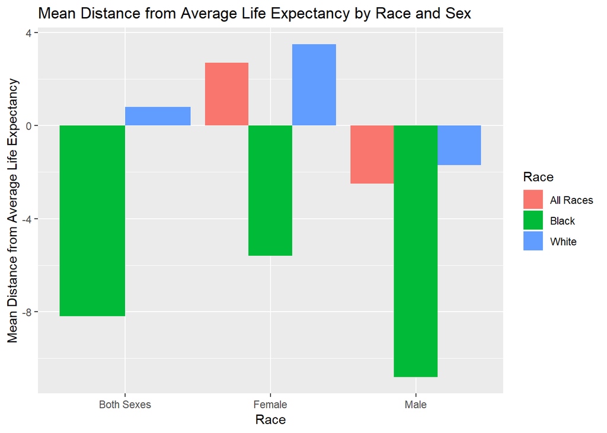

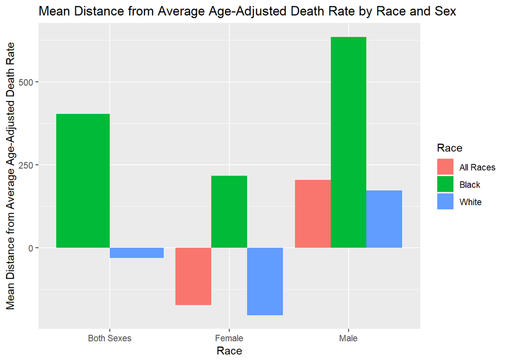

# Conclusions